Skip to contents

# 📈 Composition, stock status and trends

Source: [`vignettes/articles/status-trends.Rmd`](https://github.com/Linbojun99/faofishingreport/blob/main/vignettes/articles/status-trends.Rmd)

📦 **Data**: [FAO Global Capture Production](https://www.fao.org/fishery/collection/capture/en), release **2026.1.0** (published by FAO on 2026-03-30; catches 1950–2024), downloaded from Capture_2026.1.0.zip. Licence [CC BY 4.0](https://creativecommons.org/licenses/by/4.0/). `fao_data_info()` shows the release you use and how to cite it.

The summary analyses take any catch data: a fishing area from `fishing_area_data()`, or any subset of `load_fao_data()` (see 💾 FAO data). Their charts are saved in `figures/png/summary/` and their tables in `tables/`, with the name of the area at the start of the file names (or `label`). Each function also returns its results invisibly, so they can be assigned and used in R.

```r
FAO27 <- fishing_area_data("Atlantic, Northeast")
```

## ⚙️ Common arguments

Most functions of this article share these arguments; the tables of each function list only its own arguments.

| Argument | Meaning | Default |
| --- | --- | --- |
| `area_data` | FAO catch data: `fishing_area_data()$area_data`, or any subset of `load_fao_data()` (e.g. one country, or several fishing areas) | required |
| `plot` | Save the charts in `figures/png/summary/` | `TRUE` |
| `table` | Save the tables in `tables/` | `TRUE` |
| `lang` | Language of the chart text and names: `"en"`, `"zh"` or `"both"` | `NULL`: the language of `fao_settings()` (`"en"` unless changed) |
| `pptx` | Also save the charts as editable PowerPoint files in `figures/pptx/summary/` | `FALSE`; `fao_settings(pptx = TRUE)` changes it for all functions |
| `plot_show` | Also draw each chart in the plot window (e.g. the Plots pane of RStudio) as it is saved | `FALSE`, or `plot_show` of `fao_settings()` |
| `label` | Name at the start of the output file names | `NULL`: the fishing area of the data (or its country; `"selected_data"` for several areas and countries) |

## 🧺 Species group composition

`species_group_composition()` sums the catch by **ISSCAAP species group** (the FAO classification of species into about 50 groups, such as “Herrings, sardines, anchovies”) or by **major group** (fishes, crustaceans, molluscs, …). FAO gives no Chinese names for the groups; the Chinese names used are unofficial translations.

```r
groups <- species_group_composition(FAO27$area_data)
```

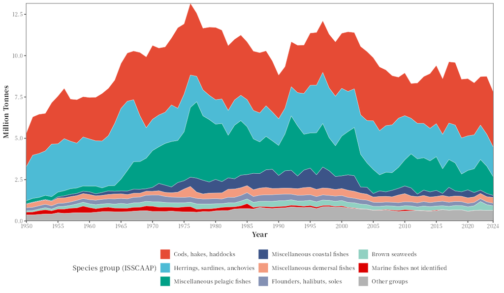

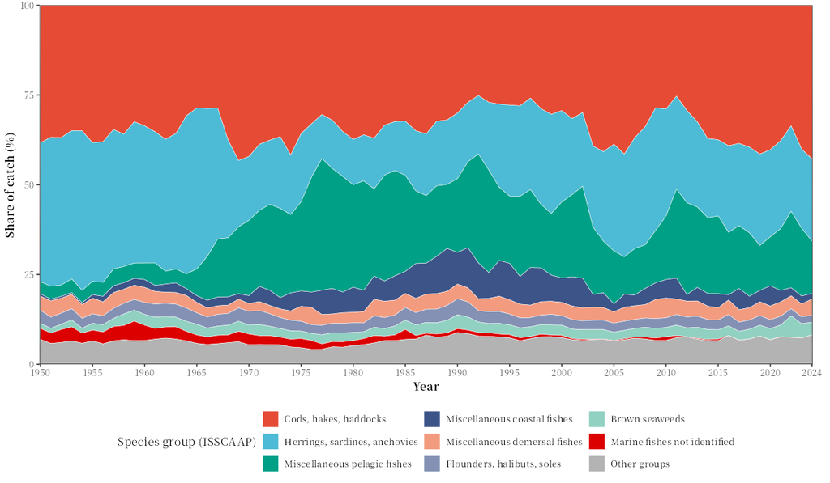

The first chart shows the catch of each group, the second its share of the yearly catch. The `top_n` largest groups are shown separately, the others combined. The table gives the mean yearly catch of each decade, the catch of each of the last five years and the share of each group in the last year (tonnes and %):

```r
show_table(groups$table, digits = 0)
```

| Species group (ISSCAAP) | 1950s | 1960s | 1970s | 1980s | 1990s | 2000s | 2010s | 2020s | 2020 | 2021 | 2022 | 2023 | 2024 | share_2024_pct |
| --- | --- | --- | --- | --- | --- | --- | --- | --- | --- | --- | --- | --- | --- | --- |
| Cods, hakes, haddocks | 2,507,170 | 3,022,010 | 4,169,322 | 3,694,448 | 2,971,859 | 3,518,007 | 3,122,258 | 3,280,509 | 3,463,440 | 3,149,488 | 2,932,054 | 3,502,551 | 3,355,012 | 43 |
| Herrings, sardines, anchovies | 2,779,324 | 3,202,760 | 1,865,383 | 1,621,417 | 2,425,069 | 2,688,692 | 2,175,941 | 1,988,596 | 2,089,755 | 2,049,083 | 2,079,641 | 1,928,844 | 1,795,658 | 23 |
| Miscellaneous pelagic fishes | 269,410 | 890,080 | 3,173,777 | 2,661,330 | 2,371,030 | 1,735,251 | 1,761,012 | 1,454,800 | 1,176,739 | 1,441,312 | 1,857,547 | 1,654,906 | 1,143,495 | 15 |
| Miscellaneous coastal fishes | 77,690 | 186,400 | 546,076 | 833,692 | 989,272 | 505,487 | 337,299 | 252,807 | 483,374 | 266,377 | 197,125 | 193,064 | 124,098 | 2 |
| Miscellaneous demersal fishes | 285,220 | 263,060 | 345,996 | 424,319 | 405,580 | 382,355 | 358,843 | 328,769 | 329,019 | 333,933 | 315,636 | 314,796 | 350,461 | 4 |
| Flounders, halibuts, soles | 203,200 | 306,580 | 346,399 | 351,725 | 340,789 | 260,697 | 250,601 | 182,052 | 213,784 | 203,179 | 172,402 | 166,824 | 154,073 | 2 |
| Brown seaweeds | 141,882 | 249,340 | 282,269 | 279,593 | 316,267 | 262,672 | 242,414 | 335,848 | 263,397 | 272,022 | 518,245 | 349,189 | 276,387 | 4 |
| Marine fishes not identified | 252,710 | 246,840 | 248,921 | 153,214 | 87,960 | 33,651 | 24,212 | 4,129 | 4,912 | 8,694 | 4,501 | 2,200 | 340 | 0 |
| Other groups | 439,560 | 563,979 | 564,321 | 716,972 | 822,271 | 696,854 | 635,533 | 631,309 | 587,282 | 634,639 | 654,495 | 637,457 | 642,670 | 8 |

```r
species_group_composition(FAO27$area_data, group = "major", lang = "zh")
```

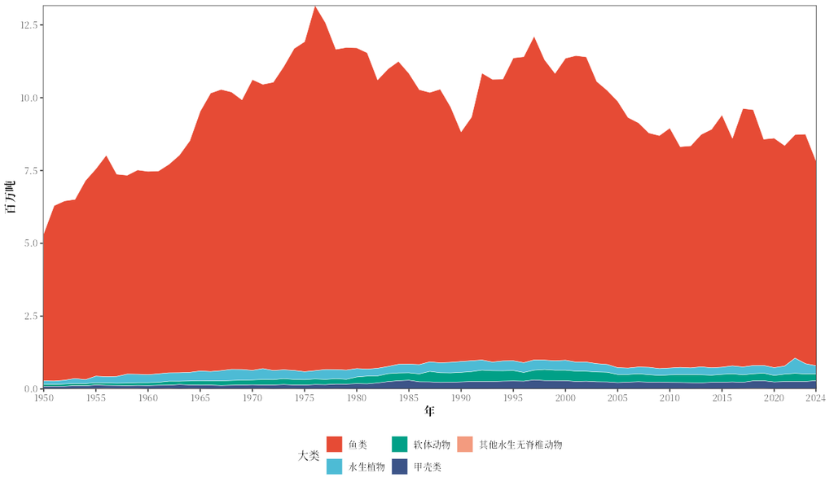

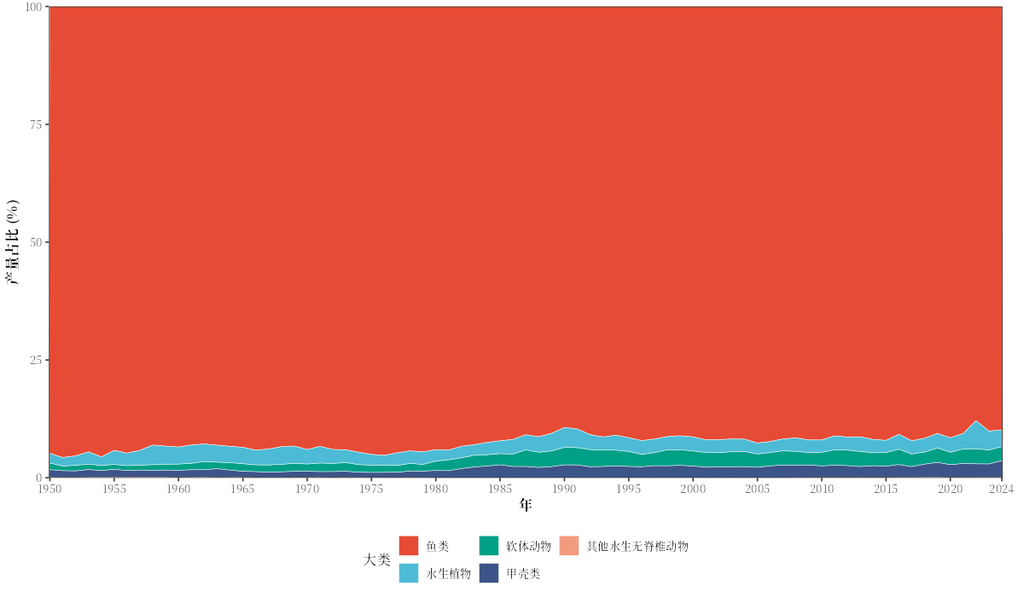

| Argument | Meaning | Default |
| --- | --- | --- |
| `group` | `"isscaap"` (ISSCAAP species groups) or `"major"` (major groups) | `"isscaap"` |
| `top_n` | Number of groups shown separately; the others are combined | `8` |
| `area_data`, `plot`, `table`, `lang`, `pptx`, `label` | See Common arguments |  |

Output: `<label>_group_isscaap.png` (or `_group_major`) and `..._share.png`, and the table `<label>_group_isscaap.csv`; the function returns `yearly` (catch by group and year) and `table`.

## 🚦 Stock status plots

`stock_status()` classifies the catch series of each species every year, by its catch relative to the **peak catch** of the series (Kleisner et al. 2013):

| Status | Rule |
| --- | --- |
| Developing | before the peak year, catch at most 50% of the peak |
| Exploited | catch above 50% of the peak |
| Over-exploited | after the peak, catch between 10% and 50% of the peak |
| Collapsed | after the peak, catch below 10% of the peak |
| Rebuilding | after a collapse, catch back between 10% and 50% of the peak |

```r
status <- stock_status(FAO27$area_data)
```

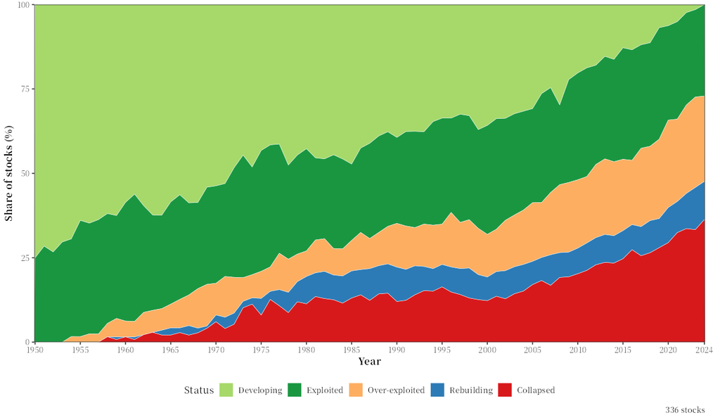

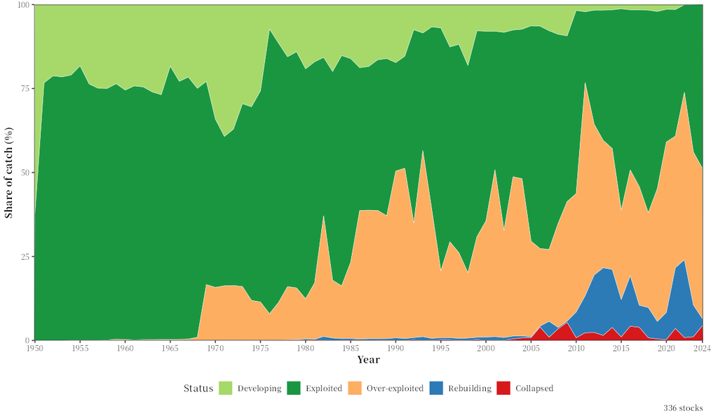

The first chart is the share of **stocks** in each status, the second the share of the **catch**. A “stock” here is one species item in the data (all countries together), and years after the last reported catch count as zero catch. Only series that meet the inclusion criteria are classified:

| Argument | Meaning | Default |
| --- | --- | --- |
| `taxon_levels` | Taxonomic levels of the items included: any of `"species"`, `"genus"`, `"family"` and `"higher"` (pooled groups such as “Marine fishes nei” are `"higher"`) | `c("species", "genus", "family")` |
| `min_years` | Minimum number of years from the first to the last year with catch | `10` |
| `min_consecutive` | Minimum number of consecutive years with catch | `5` |
| `min_catch` | Minimum total catch of a series (tonnes) | `1000` |
| `smooth` | Smooth the catch with a 3-year running mean before classifying | `FALSE` |
| `area_data`, `plot`, `table`, `lang`, `pptx`, `label` | See Common arguments |  |

The table of stocks gives the peak year and the status of each stock in the last year:

```r
show_table(status$stocks, digits = 0)
```

| species_name | species_en | first_year | peak_year | peak_tonnes | last_year_tonnes | pct_of_peak | status_last_year |
| --- | --- | --- | --- | --- | --- | --- | --- |
| Capelin | Capelin | 1950 | 1977 | 3,773,808 | 168693.267 | 4 | Collapsed |
| Atlantic herring | Atlantic herring | 1950 | 1965 | 3,736,100 | 1250851.116 | 33 | Over-exploited |
| Blue whiting(=Poutassou) | Blue whiting(=Poutassou) | 1950 | 2004 | 2,419,291 | 1832649.131 | 76 | Exploited |
| Atlantic cod | Atlantic cod | 1950 | 1969 | 2,147,600 | 762408.034 | 36 | Over-exploited |
| Atlantic mackerel | Atlantic mackerel | 1950 | 2014 | 1,382,490 | 904016.963 | 65 | Exploited |
| Sandeels(=Sandlances) nei | Sandeels(=Sandlances) nei | 1954 | 1997 | 1,242,671 | 96630.953 | 8 | Collapsed |
| European sprat | European sprat | 1950 | 1975 | 982,776 | 343221.482 | 35 | Over-exploited |
| Haddock | Haddock | 1950 | 1969 | 889,200 | 293250.936 | 33 | Over-exploited |
| Norway pout | Norway pout | 1959 | 1974 | 877,910 | 5372.615 | 1 | Collapsed |
| Saithe(=Pollock) | Saithe(=Pollock) | 1950 | 1974 | 723,652 | 299652.086 | 41 | Over-exploited |

```r
table(status$stocks$status_last_year)
```

```
#>
#>      Collapsed      Exploited Over-exploited     Rebuilding
#>            122             91             85             38
```

```r
# Smoothed catches, stricter inclusion
stock_status(FAO27$area_data, smooth = TRUE, min_catch = 10000, label = "FAO27 smoothed")
```

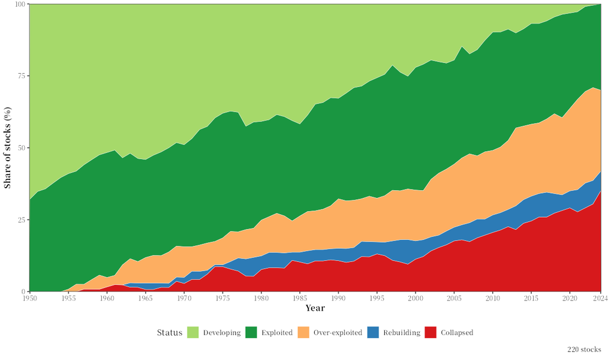

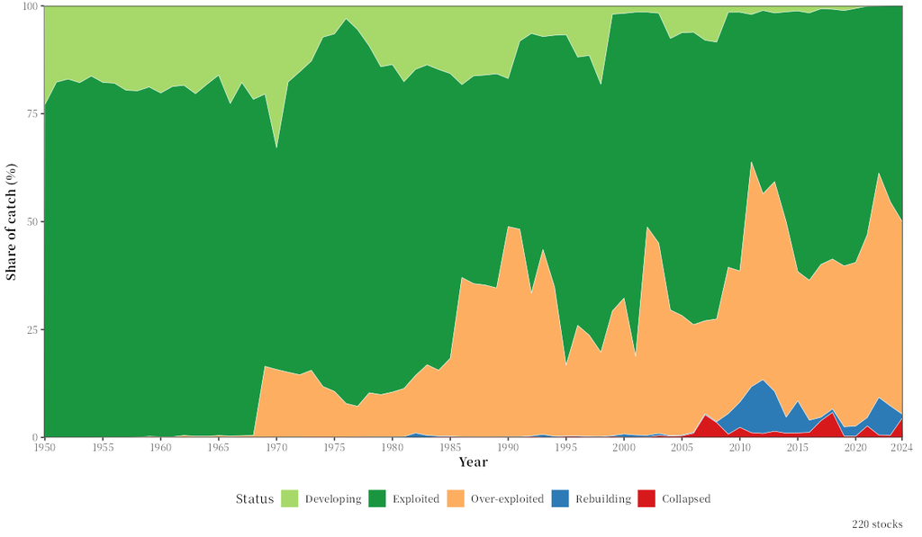

Output: `<label>_stock_status_stocks.png` and `<label>_stock_status_catch.png`, and the tables `<label>_stock_status.csv` (stocks and catch by status and year) and `<label>_stock_status_stocks.csv`; the function returns `yearly`, `stocks` and `status` (the status of each stock in each year).

Stock status plots use catch data only. A falling catch can also come from management, markets or reporting, so the results are indicative and do not replace stock assessments.

## ⛰️ Peak and trend

`peak_trend()` finds, for the total and for the main species (or countries, or areas), the year and size of the **peak catch**, the catch in the last year as a **percentage of the peak**, and the trend over the last `recent_years` years:

- **growth rate** (`growth_pct_per_year`): the average yearly growth between the first and the last of these years, $100\,[(C_n/C_1)^{1/(n-1)} - 1]$, with $C_1$ and $C_n$ the catch of the first and the last of the $n$ years;
- **trend**: a Mann-Kendall test (Mann 1945; Kendall 1975), Kendall’s τ between year and catch. Catch series are autocorrelated, which makes the usual test find too many trends, so its variance is corrected with the effective sample size of an AR(1) process (Yue and Wang 2004), from the lag-1 autocorrelation of the detrended series corrected for its small-sample bias (Kendall 1954; `lag1_autocorrelation`). `p_value` is the corrected p value and `p_value_iid` that of the usual test. `trend` is `"up"` or `"down"` when `p_value` < 0.05, otherwise `"none"`. Over ten years the correction is only partial: strongly autocorrelated series still show trends too often.
- **many series**: among ten or more series, some show a trend by chance. `q_value` adjusts the p values for the number of series in the result, the total excepted (Benjamini and Hochberg 1995). Read trends with `p_value` < 0.05 as exploratory and give as significant those with `q_value` < 0.05; 📝 the report does this for its main species and countries.

```r
species_trend <- peak_trend(FAO27$area_data, by = "species", top_n = 10)
```

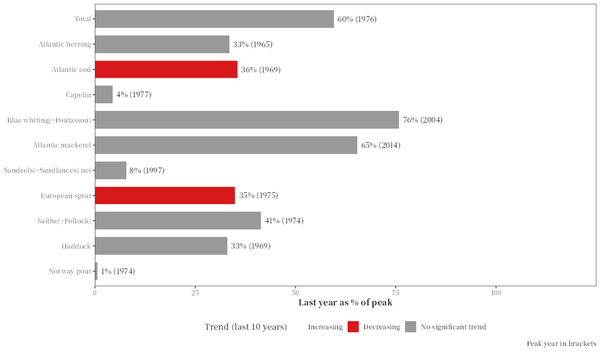

```r
show_table(species_trend[, c("name", "peak_year", "pct_of_peak", "growth_pct_per_year", "kendall_tau", "p_value", "q_value", "trend")])
```

|  | name | peak_year | pct_of_peak | growth_pct_per_year | kendall_tau | p_value | q_value | trend |
| --- | --- | --- | --- | --- | --- | --- | --- | --- |
| p | Total | 1976 | 59.53 | -2.0050033 | -0.33 | 0.21 | NA | none |
| p1 | Atlantic herring | 1965 | 33.48 | -0.4745389 | -0.20 | 0.71 | 0.95 | none |
| p2 | Atlantic cod | 1969 | 35.50 | -5.2914437 | -0.82 | 0.03 | 0.16 | down |
| p3 | Capelin | 1977 | 4.47 | -13.1229391 | -0.02 | 1.00 | 1.00 | none |
| p4 | Blue whiting(=Poutassou) | 2004 | 75.75 | 2.9400918 | 0.16 | 0.74 | 0.95 | none |
| p5 | Atlantic mackerel | 2014 | 65.39 | -3.1263873 | -0.38 | 0.33 | 0.83 | none |
| p6 | Sandeels(=Sandlances) nei | 1997 | 7.78 | -12.5836285 | -0.47 | 0.07 | 0.25 | none |
| p7 | European sprat | 1975 | 34.92 | -5.7343149 | -0.82 | 0.00 | 0.01 | down |
| p8 | Saithe(=Pollock) | 1974 | 41.41 | 0.4885031 | 0.11 | 0.84 | 0.95 | none |
| p9 | Haddock | 1969 | 32.98 | 0.3336638 | 0.07 | 0.86 | 0.95 | none |

```r
peak_trend(FAO27$area_data, by = "country", top_n = 15, recent_years = 20, lang = "zh")
```

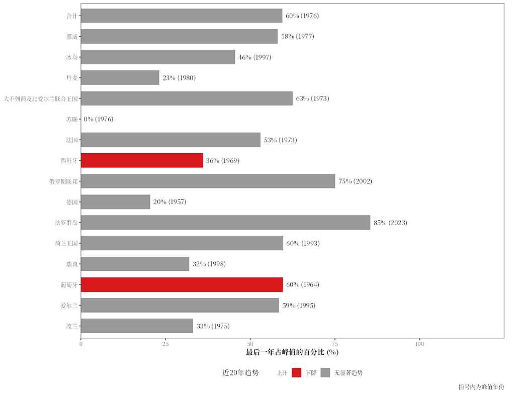

| Argument | Meaning | Default |
| --- | --- | --- |
| `by` | What to compare: `"species"`, `"country"` or `"area"` | `"species"` |
| `top_n` | Number of series with the largest total catch (`Inf` for all) | `10` |
| `recent_years` | Number of most recent years used for the trend | `10` |
| `area_data`, `plot`, `table`, `lang`, `pptx`, `label` | See Common arguments |  |

Output: `<label>_peak_trend_species.png` (or `_country`, `_area`) and the table with the same name; the function returns a data frame with one row per series, the total first.

## 🌍 All FAO marine areas

`area_overview()` compares all FAO marine fishing areas: the catch of each area over time with its peak, and the peak and trend chart of `peak_trend(by = "area")` for the areas:

```r
overview <- area_overview()
```

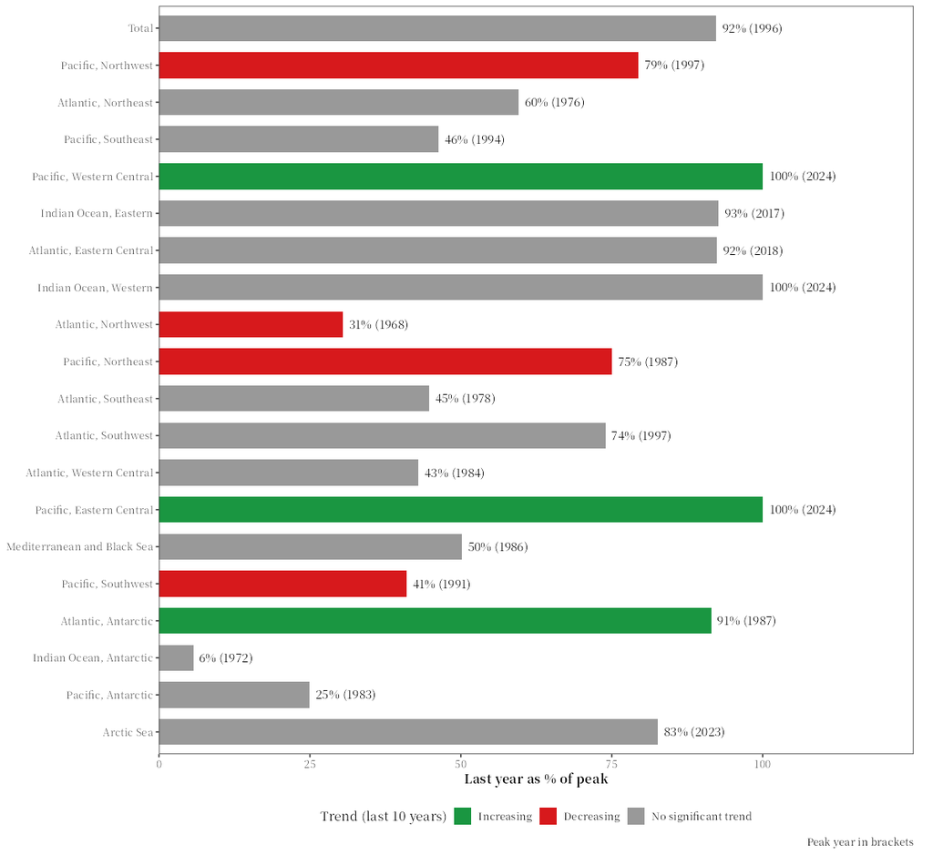

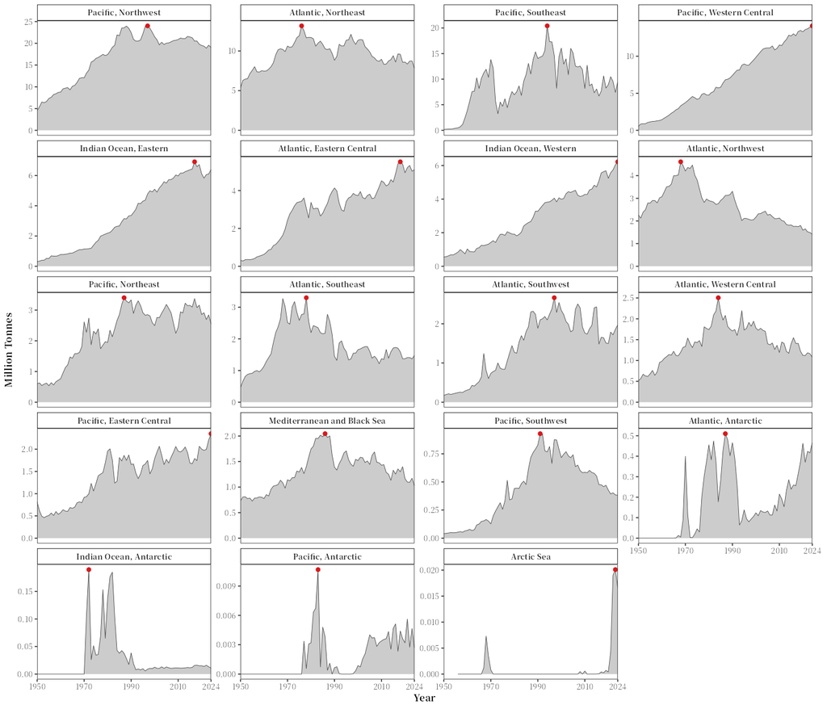

```r
show_table(overview[, c("name", "peak_year", "peak_tonnes", "last_year_tonnes", "pct_of_peak", "trend")], n = 20, digits = 0)
```

|  | name | peak_year | peak_tonnes | last_year_tonnes | pct_of_peak | trend |
| --- | --- | --- | --- | --- | --- | --- |
| p | Total | 1996 | 87,687,040 | 80930379.329 | 92 | none |
| p1 | Pacific, Northwest | 1997 | 24,020,927 | 19067991.408 | 79 | down |
| p2 | Atlantic, Northeast | 1976 | 13,172,602 | 7842194.162 | 60 | none |
| p3 | Pacific, Southeast | 1994 | 20,422,424 | 9453525.210 | 46 | none |
| p4 | Pacific, Western Central | 2024 | 14,105,189 | 14105189.055 | 100 | up |
| p5 | Indian Ocean, Eastern | 2017 | 6,910,165 | 6401679.921 | 93 | none |
| p6 | Atlantic, Eastern Central | 2018 | 5,520,055 | 5099475.194 | 92 | none |
| p7 | Indian Ocean, Western | 2024 | 6,223,934 | 6223934.387 | 100 | none |
| p8 | Atlantic, Northwest | 1968 | 4,612,569 | 1407262.000 | 31 | down |
| p9 | Pacific, Northeast | 1987 | 3,401,535 | 2551440.501 | 75 | down |
| p10 | Atlantic, Southeast | 1978 | 3,299,221 | 1475796.444 | 45 | none |
| p11 | Atlantic, Southwest | 1997 | 2,664,636 | 1970436.942 | 74 | none |
| p12 | Atlantic, Western Central | 1984 | 2,505,870 | 1077647.351 | 43 | none |
| p13 | Pacific, Eastern Central | 2024 | 2,349,505 | 2349505.260 | 100 | up |
| p14 | Mediterranean and Black Sea | 1986 | 2,046,352 | 1026111.034 | 50 | none |
| p15 | Pacific, Southwest | 1991 | 929,232 | 381352.879 | 41 | down |
| p16 | Atlantic, Antarctic | 1987 | 510,151 | 466706.916 | 91 | up |
| p17 | Indian Ocean, Antarctic | 1972 | 189,586 | 10861.059 | 6 | none |
| p18 | Pacific, Antarctic | 1983 | 10,678 | 2665.606 | 25 | none |
| p19 | Arctic Sea | 2023 | 20,094 | 16604.000 | 83 | none |

| Argument | Meaning | Default |
| --- | --- | --- |
| `recent_years` | Number of most recent years used for the trend | `10` |
| `data_version` | FAO data release to use (see `load_fao_data()`) | `"latest"` |
| `plot`, `table`, `lang`, `pptx` | See Common arguments |  |

`area_overview()` reads the FAO data itself, so it has no `area_data` or `label`. Output: `marine_areas_catch.png`, `marine_areas_peak_trend_area.png` and the table `marine_areas_peak_trend_area.csv`; the function returns the data frame of `peak_trend()`.

## 🔀 Synchronous breakpoints

`regime_shift()` runs a breakpoint analysis on the catch series of the main species (all species items, including “nei” groups) and counts how many species change their mean catch in each year. Each series is split where its mean changes (`strucchange::breakpoints()`, Bai and Perron 2003; Zeileis et al. 2002, 2003), with the number of breakpoints chosen by BIC; the year of a breakpoint is the first year of the new period. Years when many species change together may point to an ecosystem-wide regime shift, or to changes in management or reporting.

```r
shifts <- regime_shift(FAO27$area_data, top_n = 20)
```

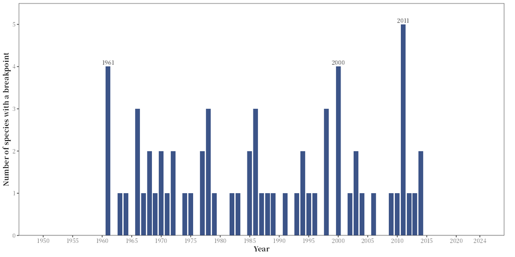

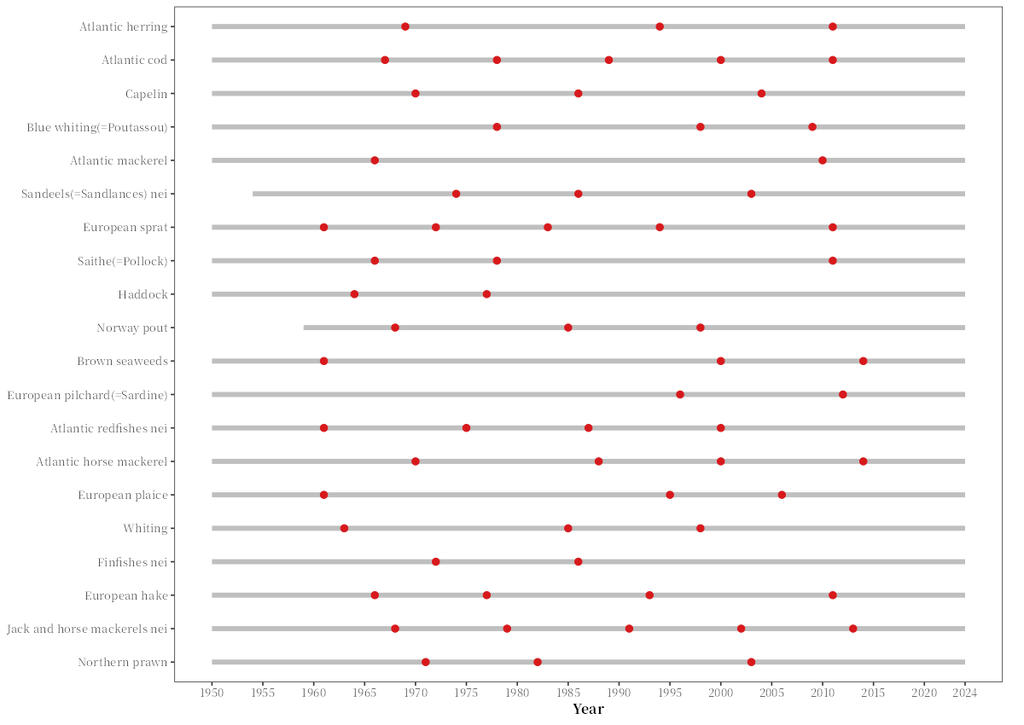

```r
show_table(shifts$breakpoints[, c("species", "first_year", "n_breakpoints", "breakpoint_years")], n = 20)
```

| species | first_year | n_breakpoints | breakpoint_years |
| --- | --- | --- | --- |
| Atlantic herring | 1950 | 3 | 1969, 1994, 2011 |
| Atlantic cod | 1950 | 5 | 1967, 1978, 1989, 2000, 2011 |
| Capelin | 1950 | 3 | 1970, 1986, 2004 |
| Blue whiting(=Poutassou) | 1950 | 3 | 1978, 1998, 2009 |
| Atlantic mackerel | 1950 | 2 | 1966, 2010 |
| Sandeels(=Sandlances) nei | 1954 | 3 | 1974, 1986, 2003 |
| European sprat | 1950 | 5 | 1961, 1972, 1983, 1994, 2011 |
| Saithe(=Pollock) | 1950 | 3 | 1966, 1978, 2011 |
| Haddock | 1950 | 2 | 1964, 1977 |
| Norway pout | 1959 | 3 | 1968, 1985, 1998 |
| Brown seaweeds | 1950 | 3 | 1961, 2000, 2014 |
| European pilchard(=Sardine) | 1950 | 2 | 1996, 2012 |
| Atlantic redfishes nei | 1950 | 4 | 1961, 1975, 1987, 2000 |
| Atlantic horse mackerel | 1950 | 4 | 1970, 1988, 2000, 2014 |
| European plaice | 1950 | 3 | 1961, 1995, 2006 |
| Whiting | 1950 | 3 | 1963, 1985, 1998 |
| Finfishes nei | 1950 | 2 | 1972, 1986 |
| European hake | 1950 | 4 | 1966, 1977, 1993, 2011 |
| Jack and horse mackerels nei | 1950 | 5 | 1968, 1979, 1991, 2002, 2013 |
| Northern prawn | 1950 | 3 | 1971, 1982, 2003 |

```r
head(shifts$yearly[order(-shifts$yearly$n_species), ], 5)
```

```
#>    Year n_species
#> 62 2011         5
#> 12 1961         4
#> 51 2000         4
#> 17 1966         3
#> 29 1978         3
```

| Argument | Meaning | Default |
| --- | --- | --- |
| `top_n` | Number of species with the largest total catch that are analysed | `20` |
| `h_value` | Minimum length of a period between breakpoints: a fraction of the series length or a number of years | `0.15` |
| `area_data`, `plot`, `table`, `lang`, `pptx`, `label` | See Common arguments |  |

Species whose series is too short for `h_value` are skipped with a message. Output: `<label>_regime_shift.png` (number of species with a breakpoint in each year), `<label>_regime_shift_species.png` (breakpoints of each species), and the tables `<label>_regime_shift.csv` and `<label>_regime_shift_years.csv`; the function returns `breakpoints` and `yearly`.

## 🐟 Pelagic/demersal ratio

`pelagic_demersal()` divides the catch of pelagic fishes by the catch of demersal fishes (P/D) in each FAO marine area, by year and by decade. Caddy (1993) proposed that nutrient enrichment favours short-lived plankton-feeding pelagic fishes over demersal fishes, and de Leiva Moreno et al. (2000) used P/D as a proxy for the nutrient level of the seas around Europe. The ratio of a decade is the mean of its yearly ratios (as Hondorp et al. 2010), with the lowest and the highest.

```r
pd <- pelagic_demersal(FAO27$area_data)
```

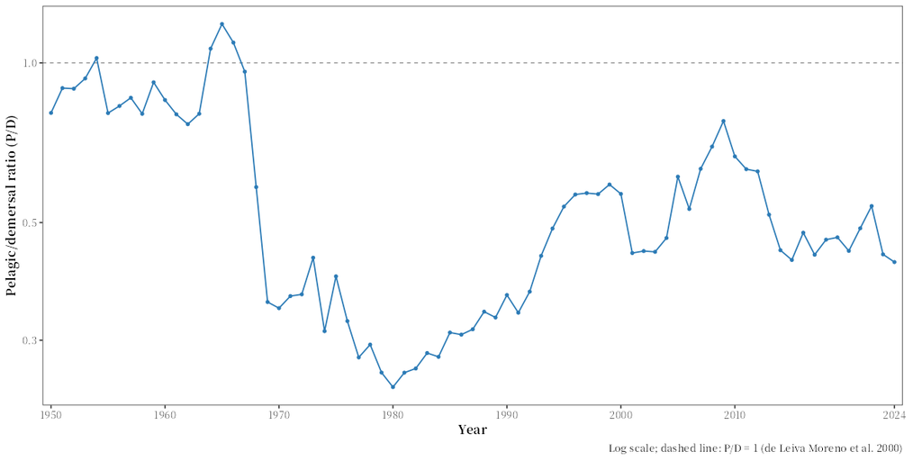

```r
show_table(pd$decades[, c("period", "pd_mean", "pd_min", "pd_max", "counted_pct")])
```

| period | pd_mean | pd_min | pd_max | counted_pct |
| --- | --- | --- | --- | --- |
| 1950s | 0.88 | 0.80 | 1.02 | 85.66 |
| 1960s | 0.85 | 0.35 | 1.18 | 79.60 |
| 1970s | 0.34 | 0.26 | 0.43 | 64.27 |
| 1980s | 0.29 | 0.24 | 0.34 | 66.68 |
| 1990s | 0.48 | 0.34 | 0.59 | 68.98 |
| 2000s | 0.56 | 0.44 | 0.78 | 75.38 |
| 2010s | 0.52 | 0.43 | 0.67 | 72.70 |
| 2020s | 0.46 | 0.42 | 0.54 | 74.33 |

```r
show_table(pd$groups[, c("group", "counted_as", "catch_pct")], n = 12)
```

| group | counted_as | catch_pct |
| --- | --- | --- |
| Cods, hakes, haddocks | demersal | 34.17 |
| Herrings, sardines, anchovies | pelagic | 24.62 |
| Miscellaneous pelagic fishes | not counted | 18.84 |
| Miscellaneous coastal fishes | demersal | 5.00 |
| Miscellaneous demersal fishes | demersal | 3.65 |
| Flounders, halibuts, soles | demersal | 2.98 |
| Brown seaweeds | not counted | 2.69 |
| Marine fishes not identified | not counted | 1.46 |
| Shrimps, prawns | demersal | 1.11 |
| Sharks, rays, chimaeras | not counted | 0.87 |
| Mussels | not counted | 0.63 |
| Clams, cockles, arkshells | not counted | 0.54 |

The FAO data give each species an ISSCAAP species group, so the function counts groups. `fao_pd_groups()` shows how each group is counted by the two published definitions (it has no arguments):

| `definition` | Pelagic | Demersal |
| --- | --- | --- |
| `"de_leiva_moreno"` (default) | Herrings, sardines, anchovies (small pelagics) | Flounders, cods and hakes, miscellaneous coastal and demersal fishes, marine crustaceans except krill |
| `"grainger_garcia"` (Grainger and Garcia 1996) | Small pelagics, tunas and billfishes, miscellaneous pelagic fishes | Flounders, cods and hakes, miscellaneous coastal and demersal fishes, sharks and rays, unidentified marine fishes |

```r
show_table(fao_pd_groups(), n = 15)
```

| isscaap_code | isscaap_en | de_leiva_moreno | grainger_garcia |
| --- | --- | --- | --- |
| 31 | Flounders, halibuts, soles | demersal | demersal |
| 32 | Cods, hakes, haddocks | demersal | demersal |
| 33 | Miscellaneous coastal fishes | demersal | demersal |
| 34 | Miscellaneous demersal fishes | demersal | demersal |
| 35 | Herrings, sardines, anchovies | pelagic | pelagic |
| 36 | Tunas, bonitos, billfishes | not counted | pelagic |
| 37 | Miscellaneous pelagic fishes | not counted | pelagic |
| 38 | Sharks, rays, chimaeras | not counted | demersal |
| 39 | Marine fishes not identified | not counted | demersal |
| 42 | Crabs, sea-spiders | demersal | not counted |
| 43 | Lobsters, spiny-rock lobsters | demersal | not counted |
| 44 | King crabs, squat-lobsters | demersal | not counted |
| 45 | Shrimps, prawns | demersal | not counted |
| 46 | Krill, planktonic crustaceans | not counted | not counted |
| 47 | Miscellaneous marine crustaceans | demersal | not counted |

Your own groups can be given with `pelagic = ...` and `demersal = ...`. The published studies classed each species rather than ISSCAAP groups, so their values (below 1 in oligotrophic seas, about 1 to 3.5 in mesotrophic and about 6 to 20 in eutrophic seas, in de Leiva Moreno et al. 2000) are only roughly comparable. P/D also changes with fishing and markets (demersal fishes are in higher demand; Caddy et al. 1998), hypoxia (Hondorp et al. 2010), the natural variability of small pelagics and reporting; see `?pelagic_demersal`. In area 27, P/D stays below 1 (by decade, between 0.29 and 0.88) although pelagic species are among the main catches: blue whiting, a pelagic gadoid, is counted with the cods, hakes and haddocks, and Atlantic mackerel (miscellaneous pelagic fishes) is not counted by this definition, which shows how much the grouping matters.

| Argument | Meaning | Default |
| --- | --- | --- |
| `definition` | Groups counted as pelagic and demersal: `"de_leiva_moreno"` or `"grainger_garcia"` | `"de_leiva_moreno"` |
| `pelagic`, `demersal` | Your own ISSCAAP groups (English names as in the FAO data, e.g. `"Herrings, sardines, anchovies"`) instead of those of `definition` | `NULL` |
| `by` | `"area"`, or `"division"` for the catch by division of `load_fao_divisions()` (🧩 extension) | `"area"` |
| `area_data`, `plot`, `table`, `lang`, `pptx`, `label` | See Common arguments |  |

Inland areas are left out with a message. Output: `<label>_pelagic_demersal_ratio.png` (P/D by year, one panel per area), `<label>_pelagic_demersal.png` and `..._share.png` (pelagic, demersal and other catch), and the tables `<label>_pelagic_demersal.csv`, `..._decades.csv` and `..._groups.csv`; the function returns `yearly`, `decades` and `groups`.

### 🧩 By division (extension)

De Leiva Moreno et al. (2000) compared the divisions of the Mediterranean and Black Sea. The same units are available from the catch data of regional fishery bodies, loaded with `load_fao_divisions()` (an extension of the package, not part of the Word report; see 🚢 Trade and employment for the other datasets):

```r
pelagic_demersal(load_fao_divisions("GFCM"), by = "division")
```

In release 2026.1.0, the mean P/D of the 1980s is below 1 in the Ionian (0.6) and the Levant (0.4), about 4 in the Adriatic and about 18 in the Black Sea, within the ranges de Leiva Moreno et al. (2000) found for oligotrophic, mesotrophic and eutrophic seas.

## 📝 In the Word report

`fao_report()` writes these analyses into the Word report of a fishing area (see 📝 Assessment report: Word, LaTeX and PDF). The ISSCAAP groups (`groups = TRUE`) and the stock status plots (`status = TRUE`) are sections by default; the pelagic/demersal ratio is added with `pelagic = TRUE`. The settings of a function are given with the section name as prefix, e.g. `status_smooth = TRUE` is `smooth = TRUE` of `stock_status()`:

```r
fao_report(27, pelagic = TRUE, status_smooth = TRUE, pelagic_definition = "grainger_garcia")
```

`peak_trend()` gives the trends in the tables of the main species and countries of the report; `area_overview()` and `regime_shift()` are not part of it.

## 📖 References

Bai, J. and Perron, P. (2003). Computation and analysis of multiple structural change models. *Journal of Applied Econometrics* 18: 1–22. [doi:10.1002/jae.659](https://doi.org/10.1002/jae.659)

Benjamini, Y. and Hochberg, Y. (1995). Controlling the false discovery rate: a practical and powerful approach to multiple testing. *Journal of the Royal Statistical Society: Series B* 57: 289–300. [doi:10.1111/j.2517-6161.1995.tb02031.x](https://doi.org/10.1111/j.2517-6161.1995.tb02031.x)

Caddy, J.F. (1993). Toward a comparative evaluation of human impacts on fishery ecosystems of enclosed and semi-enclosed seas. *Reviews in Fisheries Science* 1: 57–95. [doi:10.1080/10641269309388535](https://doi.org/10.1080/10641269309388535)

Caddy, J.F., Carocci, F. and Coppola, S. (1998). Have peak fishery production levels been passed in continental shelf area? Some perspectives arising from historical trends in production per shelf area. *Journal of Northwest Atlantic Fishery Science* 23: 191–219. [doi:10.2960/J.v23.a13](https://doi.org/10.2960/J.v23.a13)

de Leiva Moreno, J.I., Agostini, V.N., Caddy, J.F. and Carocci, F. (2000). Is the pelagic-demersal ratio from fishery landings a useful proxy for nutrient availability? A preliminary data exploration for the semi-enclosed seas around Europe. *ICES Journal of Marine Science* 57: 1091–1102. [doi:10.1006/jmsc.2000.0705](https://doi.org/10.1006/jmsc.2000.0705)

FAO (2026). *Global Capture Production 1950–2024*, release 2026.1.0. In: Fisheries and Aquaculture. Rome: FAO. https://www.fao.org/fishery/collection/capture/en. Licence: CC BY 4.0. Release file: https://www.fao.org/fishery/static/Data/Capture_2026.1.0.zip

Grainger, R.J.R. and Garcia, S.M. (1996). *Chronicles of marine fishery landings (1950–1994): trend analysis and fisheries potential*. FAO Fisheries Technical Paper 359. Rome: FAO. https://www.fao.org/4/w3244e/w3244e00.htm

Hondorp, D.W., Breitburg, D.L. and Davias, L.A. (2010). Eutrophication and fisheries: separating the effects of nitrogen loads and hypoxia on the pelagic-to-demersal ratio and other measures of landings composition. *Marine and Coastal Fisheries* 2: 339–361. [doi:10.1577/C09-020.1](https://doi.org/10.1577/C09-020.1)

Kendall, M.G. (1954). Note on bias in the estimation of autocorrelation. *Biometrika* 41: 403–404. [doi:10.1093/biomet/41.3-4.403](https://doi.org/10.1093/biomet/41.3-4.403)

Kendall, M.G. (1975). *Rank correlation methods*, 4th edition. London: Charles Griffin.

Kleisner, K., Zeller, D., Froese, R. and Pauly, D. (2013). Using global catch data for inferences on the world’s marine fisheries. *Fish and Fisheries* 14: 293–311. [doi:10.1111/j.1467-2979.2012.00469.x](https://doi.org/10.1111/j.1467-2979.2012.00469.x)

Mann, H.B. (1945). Nonparametric tests against trend. *Econometrica* 13: 245–259. [doi:10.2307/1907187](https://doi.org/10.2307/1907187)

Yue, S. and Wang, C.Y. (2004). The Mann-Kendall test modified by effective sample size to detect trend in serially correlated hydrological series. *Water Resources Management* 18: 201–218. [doi:10.1023/B:WARM.0000043140.61082.60](https://doi.org/10.1023/B:WARM.0000043140.61082.60)

Zeileis, A., Leisch, F., Hornik, K. and Kleiber, C. (2002). strucchange: an R package for testing for structural change in linear regression models. *Journal of Statistical Software* 7(2): 1–38. [doi:10.18637/jss.v007.i02](https://doi.org/10.18637/jss.v007.i02)

Zeileis, A., Kleiber, C., Krämer, W. and Hornik, K. (2003). Testing and dating of structural changes in practice. *Computational Statistics & Data Analysis* 44: 109–123. doi:10.1016/S0167-9473(03)00030-6